# Incident risk modeling — results

## Counterfactual grid search (test sample)

**What this is:** A *what-if* sensitivity check on held-out **test** rows—not proof that changing care prevents incidents.

**Feature selection (all incident types):** Top **5** logistic features that **increase** risk and top **5** that **decrease** risk.

**Percentile grid (per row, train+val reference):**

- **Increase-risk features:** from the row’s current percentile on the train distribution, step **down by 10** until **p25** (e.g. 50 → 40 → 30 → 25).
- **Decrease-risk features (inverse):** step **up by 10** until **p75**.

Each trial sets the feature to the train reference **value at that percentile**. Greedy search picks the best step per feature. Grid on **5k subsample**; implied cost on **full test**.

**Scores:** Champion model only; **no retraining**.

### Selected features (top 5 increase + top 5 decrease)

```python
cf_selected
```

|  | feature | feature_readable | incident_type | coefficient | abs_coefficient | direction | grid_direction |
| --- | --- | --- | --- | --- | --- | --- | --- |
| 0 | dx_distinct_icd | Distinct ICD codes | Wound | 1.316029 | 1.316029 | increases_risk | increase |
| 1 | vital_count_30d | Vital sign events (30d) | Fall | 1.024712 | 1.024712 | increases_risk | increase |
| 2 | tag_physician_notification_90d | Document tag (physician notification 90d) | Altercation | 0.585190 | 0.585190 | increases_risk | increase |
| 3 | age_years | Age at index (years) | Fall | 0.534926 | 0.534926 | increases_risk | increase |
| 4 | vital_count_90d | Vital sign events (90d) | Altercation | 0.503752 | 0.503752 | increases_risk | increase |
| 5 | dx_active_count | Active diagnoses | Wound | -0.959020 | 0.959020 | decreases_risk | decrease |
| 6 | outpatient | Outpatient flag | Altercation | -0.755061 | 0.755061 | decreases_risk | decrease |
| 7 | days_since_admission | Days since admission | Altercation | -0.605929 | 0.605929 | decreases_risk | decrease |
| 8 | med_on_time_rate_90d | Medication on-time rate (90d) | Altercation | -0.595680 | 0.595680 | decreases_risk | decrease |
| 9 | tag_wound_care_90d | Document tag (wound care 90d) | Altercation | -0.592780 | 0.592780 | decreases_risk | decrease |

```python
cf_rows = []
for lt, v in counterfactual['per_label'].items():
    cf_rows.append({
        'Incident type': lt,
        'Mean prob (baseline)': v['mean_predicted_prob_baseline'],
        'Mean prob (optimized)': v['mean_predicted_prob_optimized'],
        'Percent reduction': v['pct_reduction'],
    })
cf_df = pd.DataFrame(cf_rows)
cf_df
```

|  | Incident type | Mean prob (baseline) | Mean prob (optimized) | Percent reduction |
| --- | --- | --- | --- | --- |
| 0 | Fall | 0.495967 | 0.081456 | 83.576281 |
| 1 | Wound | 0.497557 | 0.066109 | 86.713273 |
| 2 | Altercation | 0.458320 | 0.079136 | 82.733425 |

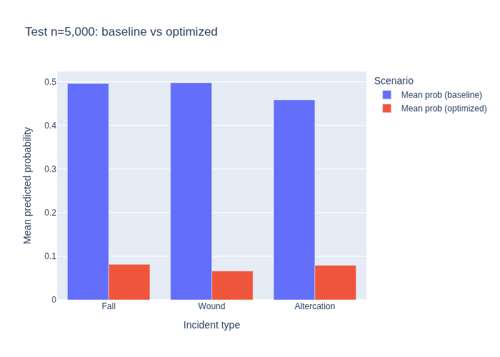

|  | feature | grid_direction | direction | incident_type | coefficient | chosen_step | chosen_percentile | avg_value_before | avg_value_after |
| --- | --- | --- | --- | --- | --- | --- | --- | --- | --- |
| 0 | dx_distinct_icd | increase | increases_risk | Wound | 1.316029 | 7 | 25.3150 | 13.964400 | 0.000000 |
| 1 | vital_count_30d | increase | increases_risk | Fall | 1.024712 | 2 | 59.1642 | 119.562000 | 0.000000 |
| 2 | tag_physician_notification_90d | increase | increases_risk | Altercation | 0.585190 | 1 | 46.0666 | 1.196400 | 0.000000 |
| 3 | age_years | increase | increases_risk | Fall | 0.534926 | 8 | 25.0000 | 75.683089 | 66.656400 |
| 4 | vital_count_90d | increase | increases_risk | Altercation | 0.503752 | 2 | 60.1520 | 338.163400 | 0.000000 |
| 5 | dx_active_count | decrease | decreases_risk | Wound | -0.959020 | 6 | 75.0000 | 14.110200 | 17.000000 |
| 6 | outpatient | decrease | decreases_risk | Altercation | -0.755061 | 0 | 50.1700 | 0.043400 | 0.043400 |
| 7 | days_since_admission | decrease | decreases_risk | Altercation | -0.605929 | 8 | 75.0000 | 672.289600 | 1100.000000 |
| 8 | med_on_time_rate_90d | decrease | decreases_risk | Altercation | -0.595680 | 0 | 54.8340 | 0.067383 | 0.074987 |
| 9 | tag_wound_care_90d | decrease | decreases_risk | Altercation | -0.592780 | 0 | 55.4400 | 1.293800 | 1.196800 |

```python
cf_long = cf_df.melt(
    id_vars=['Incident type'],
    value_vars=['Mean prob (baseline)', 'Mean prob (optimized)'],
    var_name='Scenario', value_name='Mean predicted probability',
)
fig_cf = px.bar(cf_long, x='Incident type', y='Mean predicted probability', color='Scenario',
    barmode='group', title=f"Test n={counterfactual['n_test_sample']:,}: baseline vs optimized")
fig_cf.show()
cf_plan
```

## Test implied cost (baseline vs optimized)

On the **full held-out test set**, implied cost = Σ (predicted probability × README average cost per incident type). **Baseline** uses the champion model on unmodified features; **optimized** applies the counterfactual feature plan from the grid search (same reductions, replayed on all test rows). Historical monthly forecast remains in `reports/scenario_summary.json`.

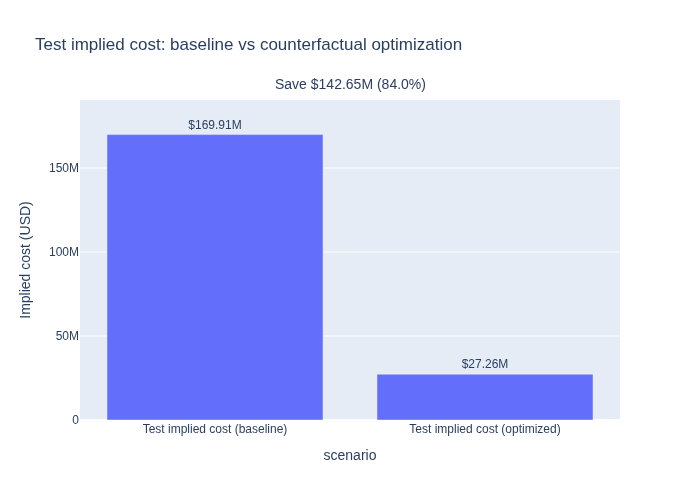

```python
def _fmt_cost(x: float) -> str:
    if x >= 1_000_000:
        return f'${x/1e6:.2f}M'
    if x >= 1_000:
        return f'${x/1e3:.0f}K'
    return f'${x:,.0f}'

compare = pd.read_csv(REPORTS / 'test_cost_scenario_compare.csv')
baseline = test_cost['baseline_total']
optimized = test_cost['optimized_total']
savings = test_cost['savings']
savings_pct = test_cost['savings_pct']

compare['label'] = compare['expected_cost'].map(_fmt_cost)
fig_cost = px.bar(
    compare, x='scenario', y='expected_cost',
    text='label',
    title='Test implied cost: baseline vs counterfactual optimization',
)
fig_cost.update_traces(textposition='outside')
fig_cost.add_annotation(
    text=f'Save {_fmt_cost(savings)} ({savings_pct:.1f}%)',
    xref='paper', yref='paper', x=0.5, y=1.08, showarrow=False,
    font=dict(size=14),
)
fig_cost.update_layout(yaxis_title='Implied cost (USD)', uniformtext_minsize=10)
fig_cost.show()
```